# Voter Mistakes Take Election

Case Study 1

Author

Leah Levensailor

Published

October 3, 2025

## Introduction

The US presidential election of 2000 has been brought to our attention because of how close the voter margin was. The votes were so close that Democratic nominee Al Gore had both conceded and taken back his concession all in one night. At the end of the day a recount was needed because of the close margin. While the recount was underway, the voters of Palm Beach County, Florida were upset about the confusing ballot operation this election. The ballot supposedly tripped people up thinking they were voting for Gore when they were actually voting for the reform candidate Pat Buchanan.

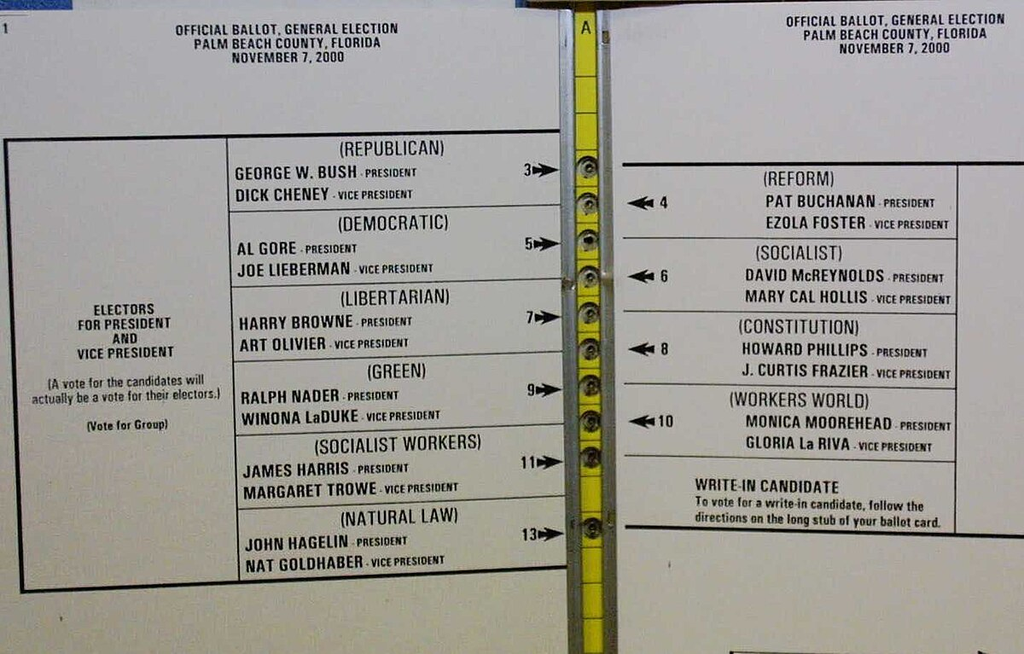

The question we are trying to answer is is there sufficient evidence that people were voting for Buchanan thinking they were actually voting for Gore. This came up because of the unusually high number of votes Buchanan got in that specific county. Below shows the tests I’ve run to see if this claim is true. The data we have is a collection of the number of votes for Bush and Buchanan in all of the counties in Florida.

```r
library(tidyverse)
library(broom)
# Reading in and saving the data
election <- Sleuth2::ex0825

# Creating a second dataset with Palm Beach County excluded
election_wo_pb <- election |>
  filter(County != "Palm Beach")
```

### Transforming the data

The data in its original form is not linear and is clumped towards the bottom left corner. Because of this I performed a logarithmic transformation on the explanatory and reposne variables. This resulted in a drastically more linear scatterplot.

```r
#transforming the data by logs
transformed_bush <- log(election_wo_pb$Bush2000)
transformed_buc <- log(election_wo_pb$Buchanan2000)

#mutating the data frame to include these new values
t_elections_wo_pb <- election_wo_pb |>
  mutate(Bush2000 = transformed_bush) |>
  mutate(Buchanan2000 = transformed_buc)
```

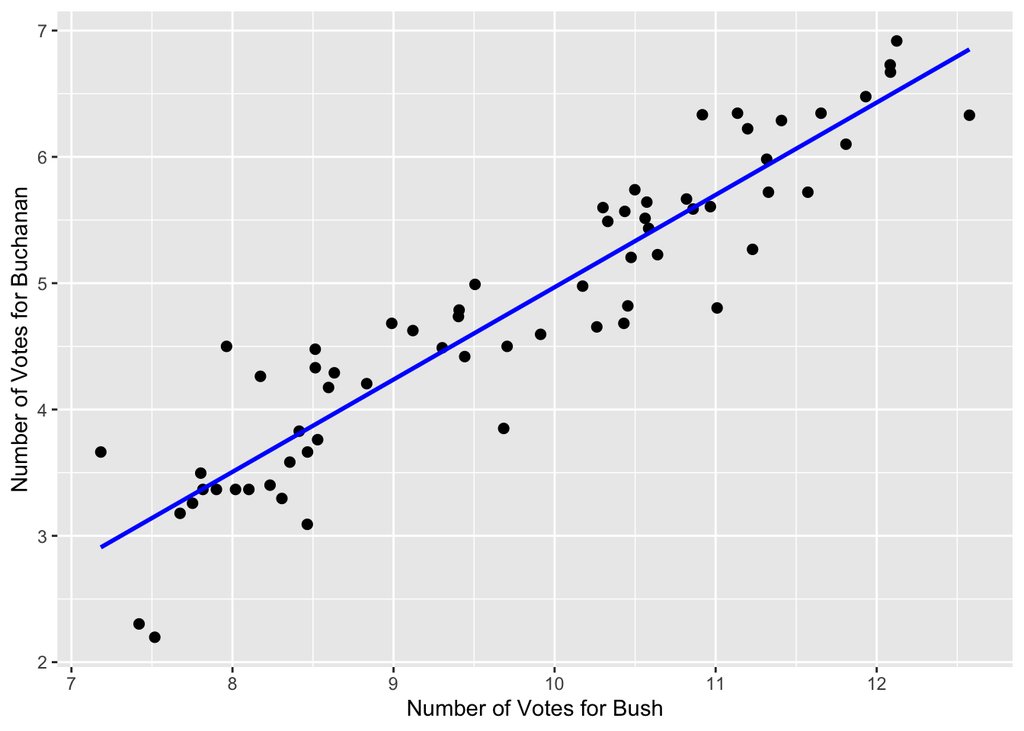

```r
#plotting the newly transformed data
t_elections_wo_pb |>
  ggplot(aes(x = Bush2000, y = Buchanan2000)) +
  geom_point(size = 2) +
  scale_x_continuous(labels = scales::label_comma()) +
  xlab("Number of Votes for Bush") +
  ylab("Number of Votes for Buchanan") +
  geom_smooth(method = "lm", se = FALSE, color = "blue")
```